# Genomic Prediction

Kyle Parker

for more information: doi: 10.1534/genetics.114.164442.

```r
#install.packages("BGLR") #install the BGLR package
library(BGLR)
#install.packages("rrBLUP") #install the rrBLUP package
library(rrBLUP)
```

Loading and preparing the input data

Wheat line data set #### comprised of 599 lines; 4 locations; Pedigree; Marker matrix Loaded from the BGLR sample wheat data set

```r
data(wheat) # wheat lines data
Y<-wheat.Y # (599 lines, 4 location) (records are centered and standardized to a unit variance within environment)
X<-wheat.X # 1,279 Diversity Array Technology (DArT) markers
A<-wheat.A #pedigree relatioship matrix
y<-Y[,1] # Yeild for Environment 1
```

```r
rrblup<-mixed.solve(y,Z=X)
```

This is some information from the rrblup documentation about what is needed for the mixsolve function. I recommend looking over the documentation for all new tools you use. Mixsolve y Vector (n × 1) of observations. Missing values (NA) are omitted, along with the corresponding rows of X and Z. Z Design matrix (n × m) for the random effects. If not passed, assumed to be the identity matrix. K Covariance matrix (m × m) for random effects; must be positive semi-definite. If not passed, assumed to be the identity matrix. X Design matrix (n × p) for the fixed effects. If not passed, a vector of 1’s is used to model the intercept. X must be full column rank (implies β is estimable)

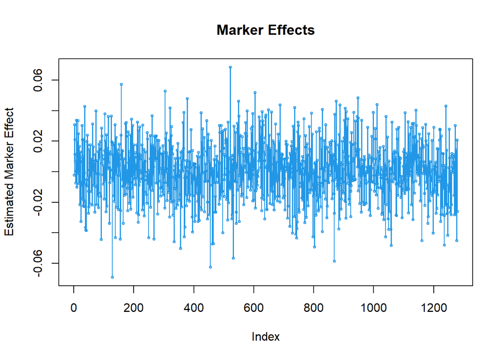

```r
plot(rrblup$u, ylab='Estimated Marker Effect',
     type='o',cex=.5,col=4,main='Marker Effects')
```

rrblup$u gives us the list of estimated marker effects.

# Bayesian Models

Next, let us evaluate other models which require a whole marker set as input. Using the BGLR package to run some Bayesian models

BGLR requires you to load the model in this format, list(effect1=list(X=markers, model=“model”)) first lets run the Bayesian ridge regression model (BRR)

```r
BRR<-list(list(X=X, model='BRR')) #Gaussian prior
BRR<-BGLR(y=y,ETA=BRR, nIter=5000, burnIn=1000, thin = 5) #1000 interactions in total
```

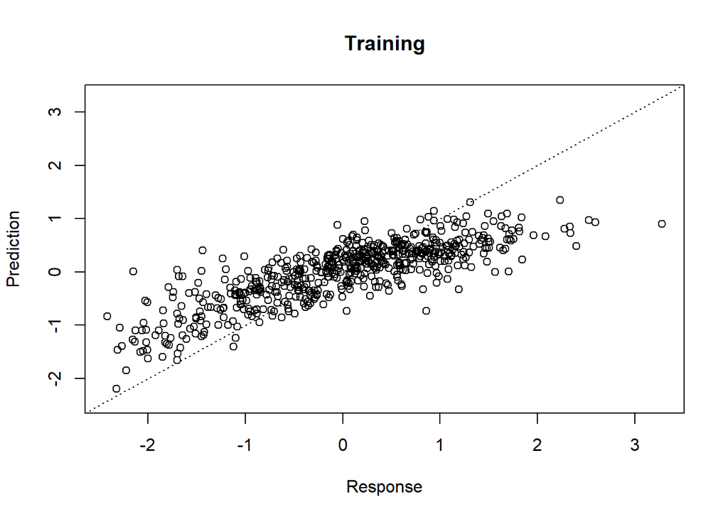

```r
plot(BRR) #plot graph pred x observed
```

```r
cor(BRR$y,BRR$yHat) #calculate correlation
```

```
## [1] 0.8163759
```

Here we can see the accuracy of the model on known data. With this model the whole population is a training set. No new predictions have been made.

Which makes sense why the accuracy is so high ~0.8 and the plot looks very good.

Now we can extract results from the model

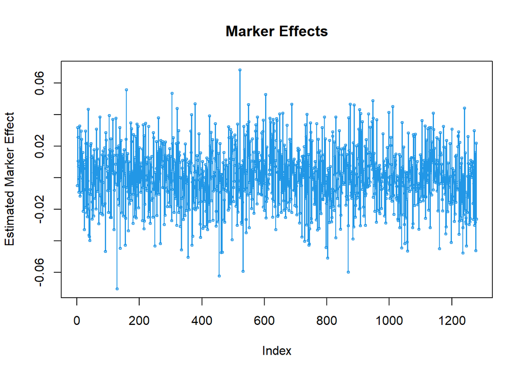

```r
bHat <- BRR$ETA[[1]]$b # Estimated Marker Effects
SD.bHat <- BRR$ETA[[1]]$SD.b
plot(bHat, ylab='Estimated Marker Effect',
     type='o',cex=.5,col=4,main='Marker Effects')
```

```r
unlink("*.dat") #delete files created by BGLR
```

Notice that the BRR model is very similar to that of the rrBLUP model. Now lets look at the Bayesian Lasso model to compare.

```r
BL<-list(list(X=X, model='BL')) #Gaussian prior
BL<-BGLR(y=y,ETA=BL, nIter=5000, burnIn=1000, thin = 5) #1000 interactions in total
```

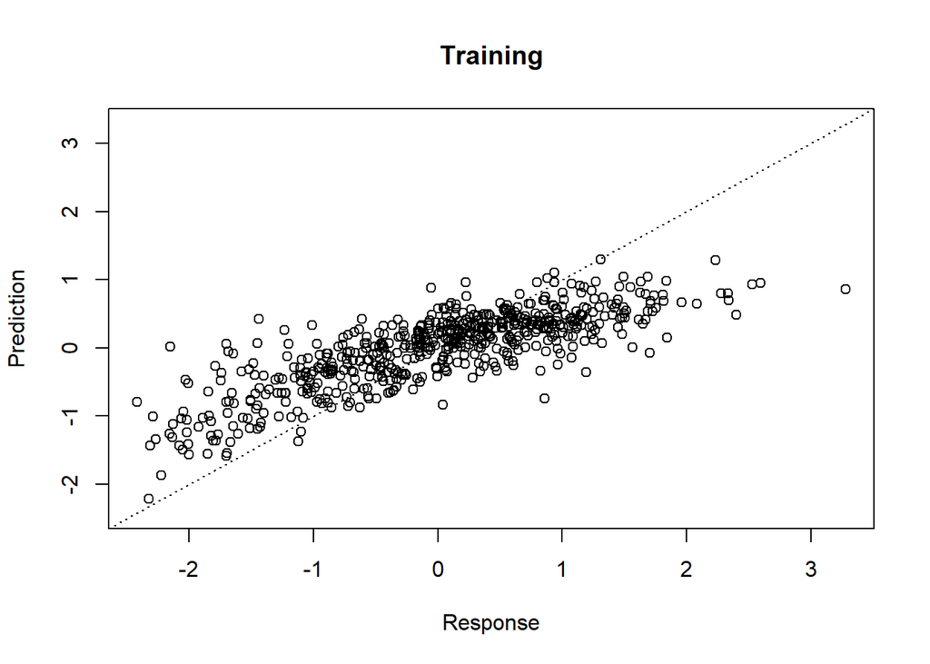

```r
plot(BL) #plot graph pred x observed
```

```r
cor(BL$y,BL$yHat) #calculate correlation
```

```
## [1] 0.806341
```

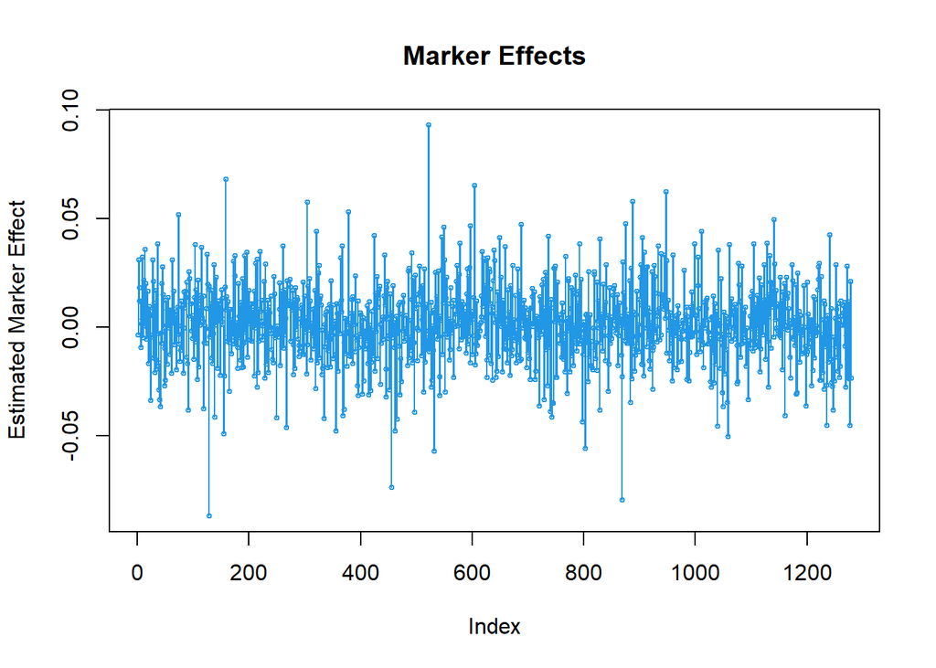

```r
bHat <- BL$ETA[[1]]$b # Estimated Marker Effects
SD.bHat <- BL$ETA[[1]]$SD.b
plot(bHat, ylab='Estimated Marker Effect',
     type='o',cex=.5,col=4,main='Marker Effects')
```

Notice how for the BL marker effects, most have a low effect, while a few SNPs have a much higher effect lambda (regularization parameter of the Bayesian Lasso)

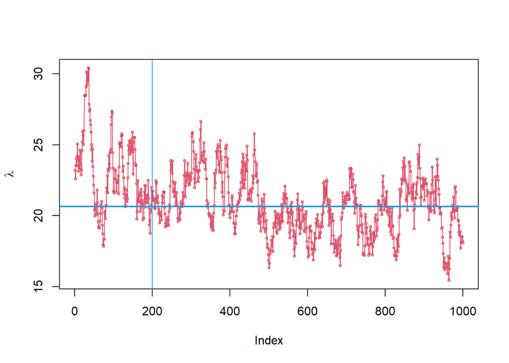

```r
lambda<-scan('ETA_1_lambda.dat')
plot(lambda,type='o',col=2,cex=.5,ylab=expression(lambda))
abline(h=BL$ETA[[1]]$lambda,col=4,lwd=2)
abline(v=BL$burnIn/BL$thin,col=4)
```

```r
unlink("*.dat") #delete files created by BGLR
```

# GRM models

now lets look at building a Genomic relationship matrix and running those models

First lets calculate our GRM. A.mat generates an additive relational matrix or you can do similarly by:

X<-scale(X,center=TRUE,scale=TRUE) G<-tcrossprod(X)/p #VanRaden (2008)

```r
GRM<-A.mat(X)
dim(GRM)
```

```
## [1] 599 599
```

here we see we took a longer marker file and now we have an nxn matrix with the 599 genotypes

GBlup originally started with animal breeders using pedigree based relationship matrix to help with predictions before we had plenty of marker data.

Lets look at the differences, the sample data set comes with a pedigree matrix (A), this can be used in place of any GRM, but generally accuracies will be lower than using markers.

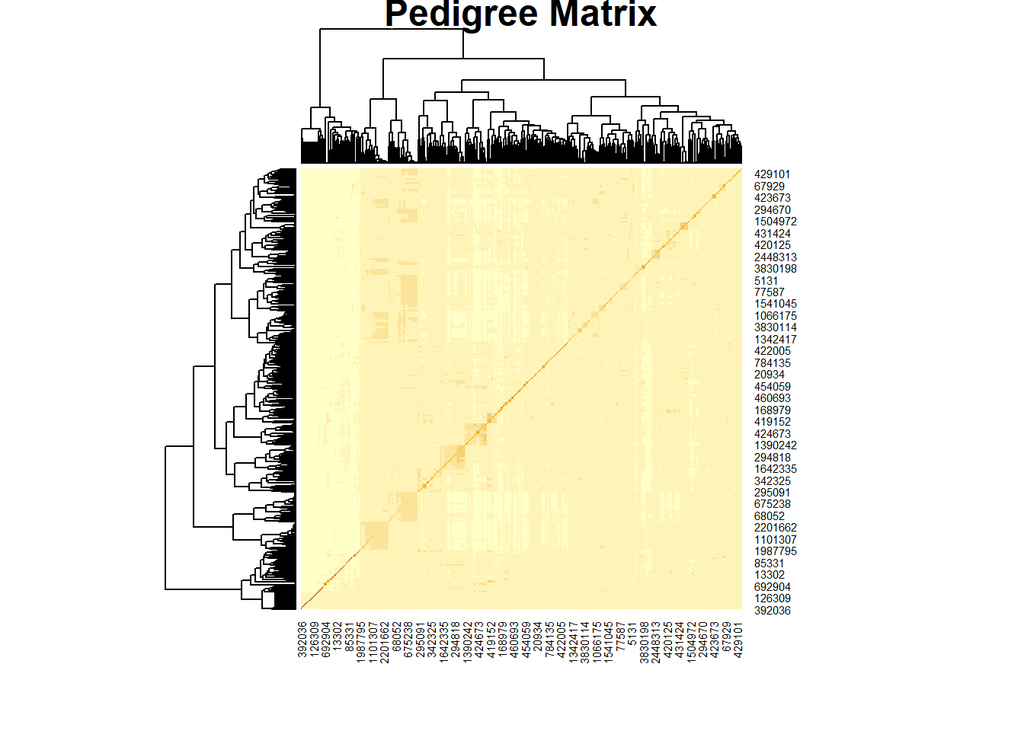

```r
heatmap(wheat.A,main = "Pedigree Matrix")
```

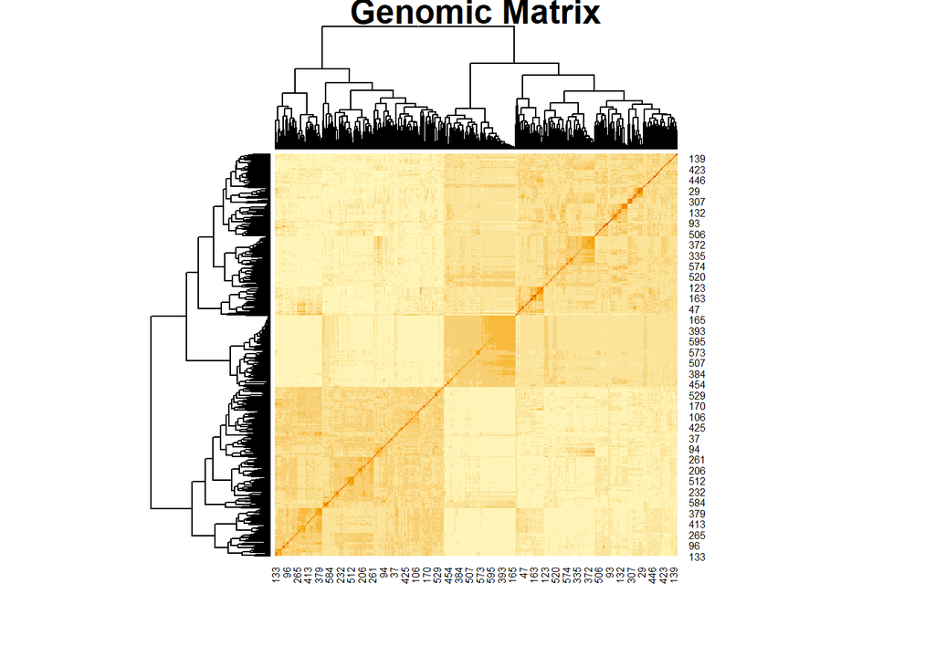

```r
heatmap(GRM,main="Genomic Matrix")
```

We can see that the genomic matrix revealed much more hidden underlying relationships that were not present in the pedigree matrix.

Now we can look at some models like GBLUP. First GBLUP likes to have your data structured with a col. for Line names, and a col for trait values. So we will combine them.

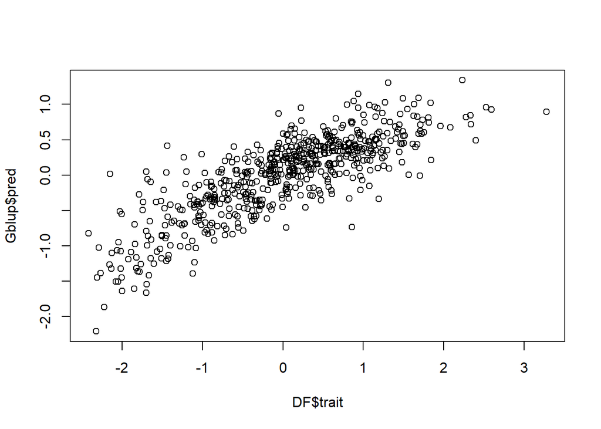

```r
DF<-data.frame('geno'=rownames(Y),'trait'=Y[,1])
colnames(GRM)<-rownames(Y)
rownames(GRM)<-rownames(Y)
Gblup<-kin.blup(data=DF,geno='geno',pheno = 'trait',K=GRM)
plot(DF$trait,Gblup$pred)
```

```r
cor(DF$trait,Gblup$pred) #calculate correlation
```

```
## [1] 0.8144891
```

One thing that you can do with these prediction models is to calculate a sort of heritablility using the estimated genetic varaince components. For example:

```r
Gblup$Vg/(Gblup$Vg + Gblup$Ve)
```

```
## [1] 0.6695916
```

This can be useful when trying to understand the predictability of a trait or performance of a model.

Lastly for Today we can look at how to code the RHKS model in BGLR. THis is a semi-parametric Gblup type model. Here instead of X= markers, we code K=GRM.

```r
RKHS<-list(list(K=GRM, model='RKHS')) #Gaussian prior
RKHS<-BGLR(y=y,ETA=RKHS, nIter=5000, burnIn=1000, thin = 5) #1000 interactions in total
```

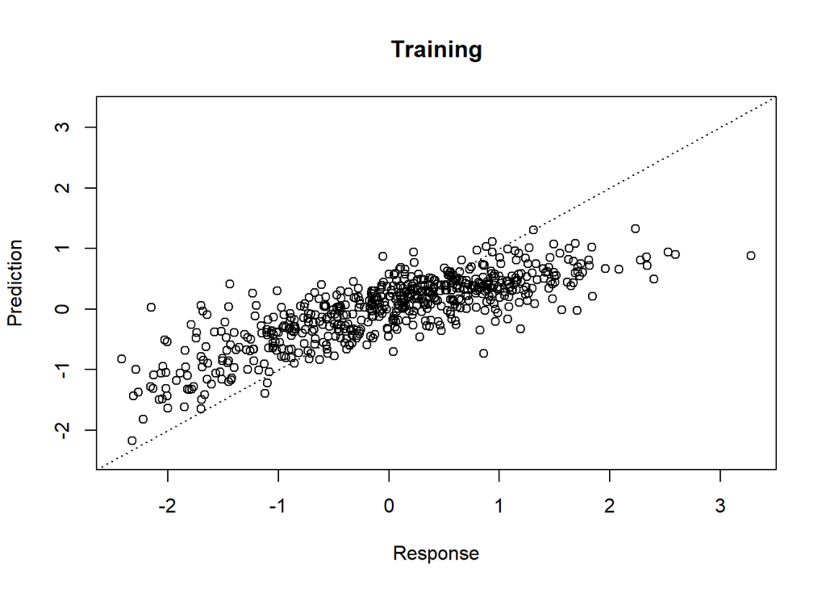

```r
plot(RKHS) #plot graph pred x observed
```

```r
cor(RKHS$y,RKHS$yHat) #calculate correlation
```

```
## [1] 0.812201
```

# Lets Compare the models

```r
print(paste0("GBLUP prediction accuracy ",cor(DF$trait,Gblup$pred),sep=""))
```

```
## [1] "GBLUP prediction accuracy 0.814489088444505"
```

```r
print(paste0("RHKS prediction accuracy ",cor(RKHS$y,RKHS$yHat),sep=""))
```

```
## [1] "RHKS prediction accuracy 0.812200992129371"
```

```r
print(paste0("BL prediction accuracy ",cor(BL$y,BL$yHat),sep=""))
```

```
## [1] "BL prediction accuracy 0.806341022921919"
```

```r
print(paste0("BRR prediction accuracy ",cor(BRR$y,BRR$yHat),sep=""))
```

```
## [1] "BRR prediction accuracy 0.816375850331233"
```

# With a Training and Testing set

So far we have just compared models, but I will now give an example with a 5-fold cross validation. First we will begin by creating 5 folds randomly in the data. Then for each of the 5 folds, we will set one to missing, then use the 80% training data to predict the missing 20%.We will then do that all 5 times, and the average of those 5 accuracies is the overall accuracy of that replication.

For simplicity we will Start with the GBLUP model.

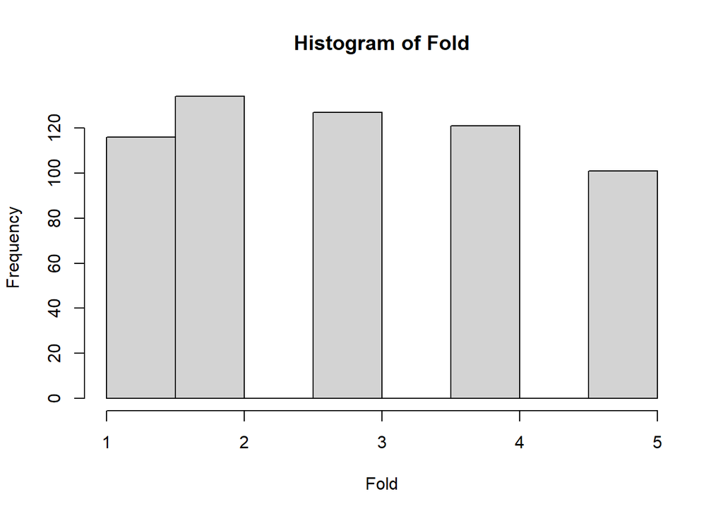

```r
Fold<-sample(1:5,nrow(DF),replace = T)
hist(Fold) # we can see it is roughly evenly distributed.
```

```r
Corrs<-c()
for(i in 1:5){ #This sets the cycle to do all 5 folds
DF2<-DF
DF2$trait[which(Fold==i)]<-NA
fm<-kin.blup(data=DF2,geno = 'geno',pheno = 'trait')
singlefold<-cor(fm$pred[which(Fold==i)],DF[which(Fold==i),'trait'],use = 'complete.obs')
Corrs<-c(Corrs,singlefold)
}

GBLUP2<-mean(Corrs)
print(GBLUP2)
```

```
## [1] 0.15007
```

See here we have a much lower prediction accuracy of ~0.15 in comparison to the ~0.8 when we were predicting known data.

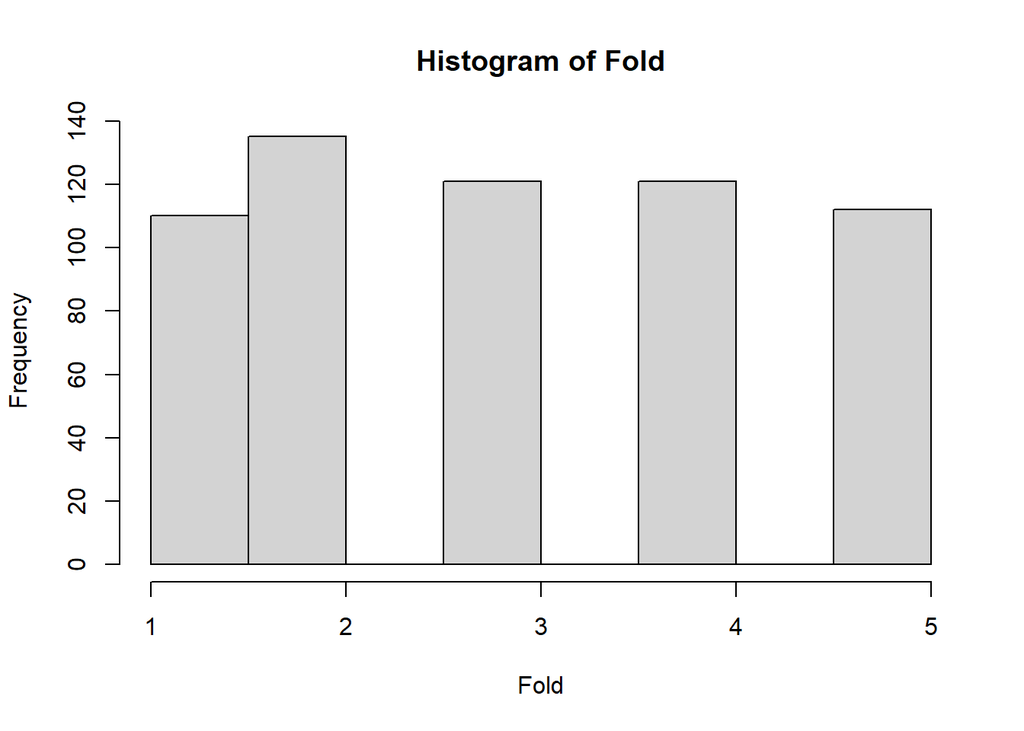

```r
Fold<-sample(1:5,nrow(DF),replace = T)
hist(Fold) # we can see it is roughly evenly distributed.
```

```r
Corrs<-c()
ETA<-list(list(X=X, model='BRR')) #Gaussian prior
for(i in 1:5){ #This sets the cycle to do all 5 folds
y<-DF$trait
y[which(Fold==i)]<-NA
BRR<-BGLR(y=y,ETA=ETA, nIter=5000, burnIn=1000, thin = 5) #1000 interactions in total
singlefold<-cor(BRR$yHat[which(Fold==i)],DF[which(Fold==i),'trait'],use = 'complete.obs')
Corrs<-c(Corrs,singlefold)
}

BRR2<-mean(Corrs)
print(BRR2)
```

```
## [1] 0.4971393
```

Here we can compare the two models

```r
print(paste0("BRR with 5Fold CV ",BRR2))
```

```
## [1] "BRR with 5Fold CV 0.497139304230729"
```

```r
print(paste0("GBLUP with 5Fold CV ",GBLUP2))
```

```
## [1] "GBLUP with 5Fold CV 0.150070049330446"
```